# ggplot2: Overview

## Advantages of ggplot2

- Based on the **grammar of graphics**
- Uses a consistent 'language' to produce different plots
- Very flexible, particularly for complex plots
- Everything is editable
- Theme system for consistent plots

## What is the grammar of graphics?

Basic idea: Specify plot building blocks and combine them to produce a plot.

- Data. Always use a `data.frame`
- Aesthetics. Mapping of your data to a plot aesthetic (position/colour/fill/shape)
- Geometries. Points/Lines/Boxplots/Histograms etc.
- Statistical transformations
- Scales and coordinate systems
- Position adjustments
- **Faceting** (small multiple plots)

## ggplot2 vs base graphics

- For simple plots, base is usually less verbose to code.
- For more complex plots, ggplot2 is usually less verbose.
- ggplot2 **requires** everything to be in a `data.frame` with a single observation per row (aka tidy data).
- base tends to use vectors (the formula form is a bit more like ggplot though)

## Example: A simple histogram

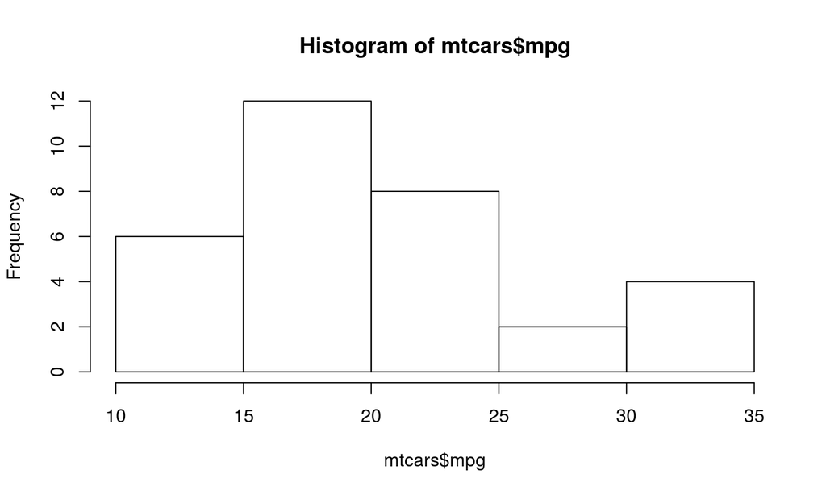

```r
hist(mtcars$mpg)
```

## Example: A simple histogram

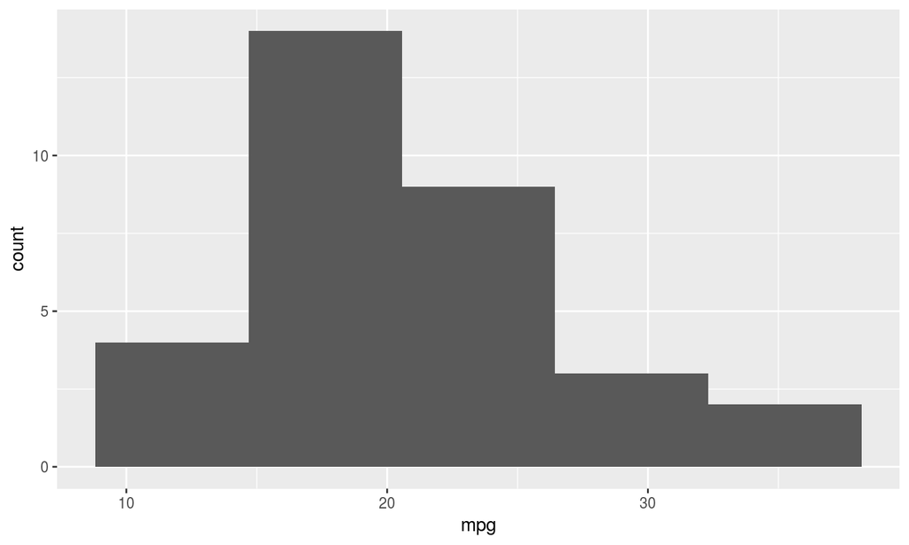

```r
library(ggplot2)
ggplot(mtcars, aes(x=mpg)) + geom_histogram(bins=5)
```

## Example: Slightly more complex

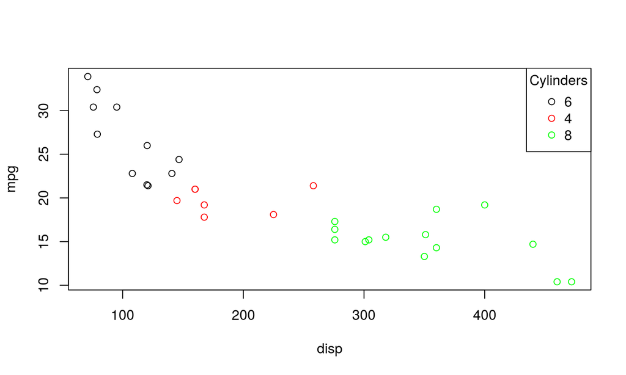

```r
plot(mpg ~ disp, data=subset(mtcars, cyl==4), xlim=range(mtcars$disp),
     ylim=range(mtcars$mpg))
points(mpg ~ disp, data=subset(mtcars, cyl==6), col='red')
points(mpg ~ disp, data=subset(mtcars, cyl==8), col='green')
legend('topright', legend=unique(mtcars$cyl), col=c('black', 'red', 'green'),
       pch=1, title='Cylinders')
```

## Example: Slightly more complex

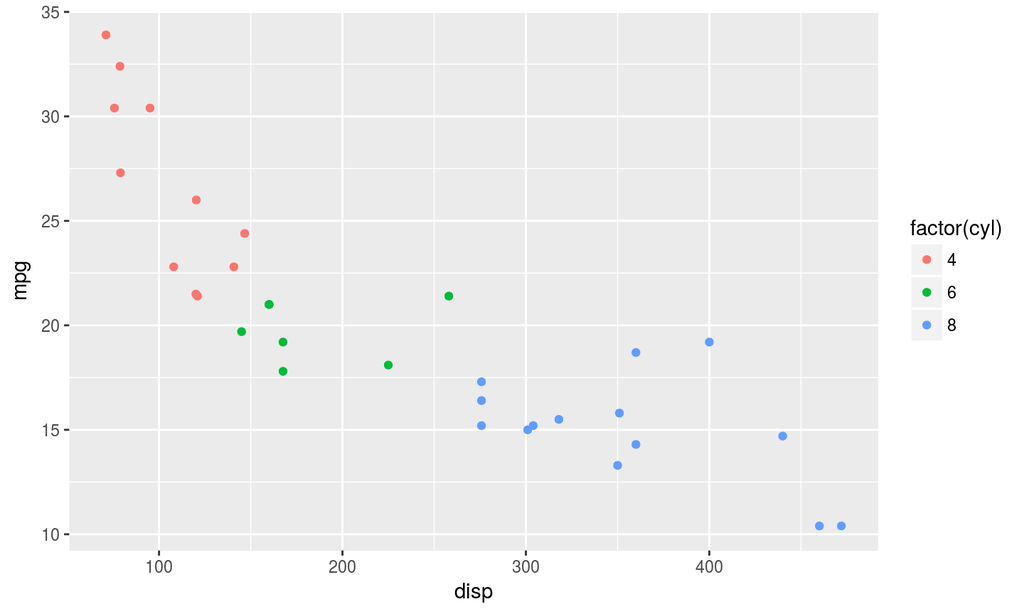

```r
ggplot(mtcars, aes(x=disp, y=mpg, col=factor(cyl))) + geom_point()
```

## Example: Slightly more complex

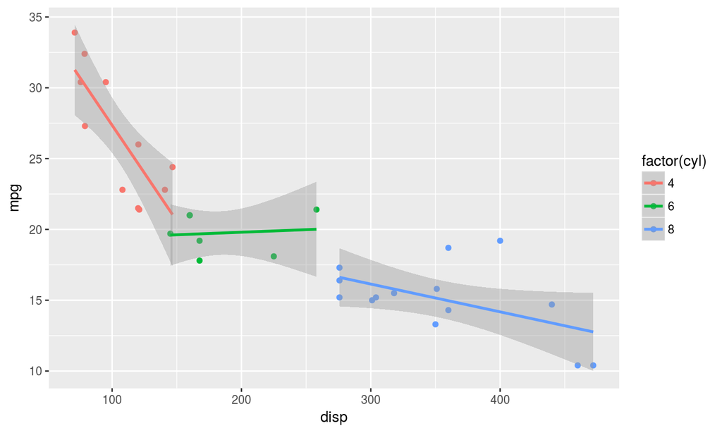

```r
ggplot(mtcars, aes(x=disp, y=mpg, col=factor(cyl))) + geom_point() +
  geom_smooth(method='lm')
```

## Aesthetic mapping

Each aesthetic on the plot can either be the same or change per data point from a column in the `data.frame`

- Position: x, y
- Colour: Outside color
- Fill: Inside color
- Shape
- Line type
- Size

## Example: Changing constant aesthetics (wrong)

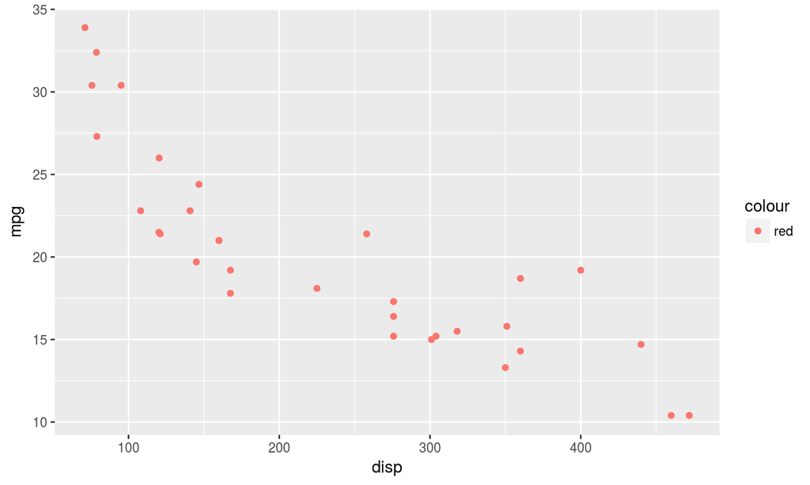

```r
ggplot(mtcars, aes(x=disp, y=mpg)) + geom_point(aes(col = 'red'))
```

## Example: Changing constant aesthetics (right)

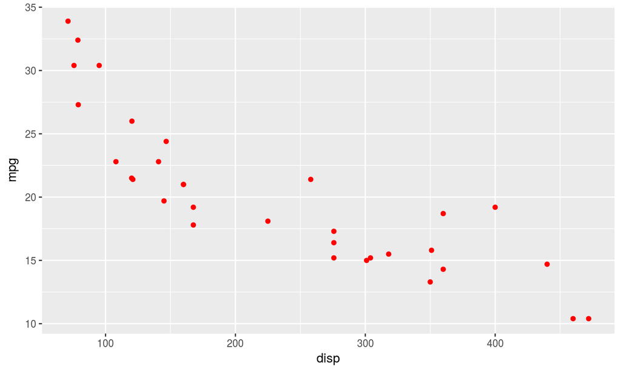

```r
ggplot(mtcars, aes(x=disp, y=mpg)) + geom_point(col = 'red')
```

## Example: Changing variable aesthetics

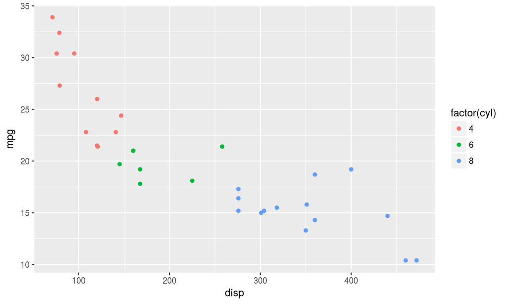

```r
ggplot(mtcars, aes(x=disp, y=mpg)) + geom_point(aes(col = factor(cyl)))
```

## Example: Lots of other aesthetics

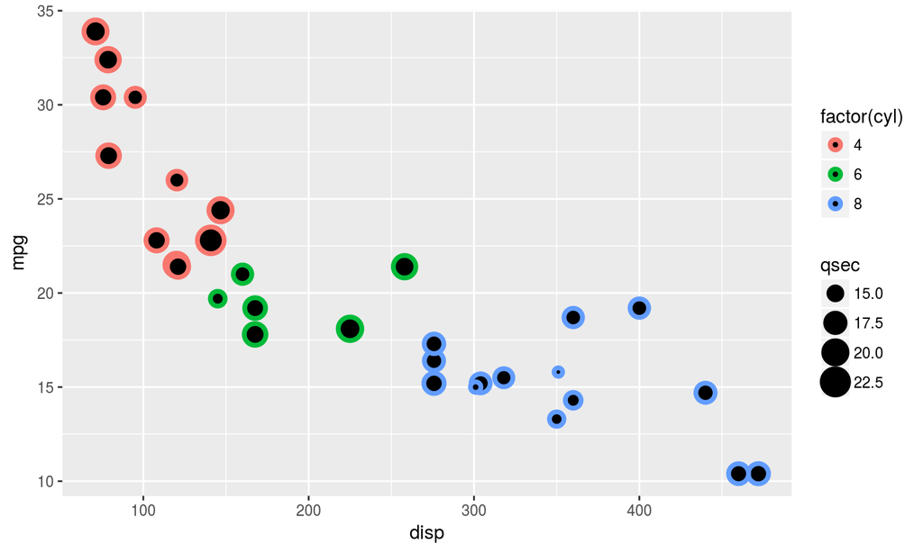

```r
ggplot(mtcars, aes(x=disp, y=mpg)) +
  geom_point(aes(col = factor(cyl), size=qsec), shape=21, stroke=2, fill='black')
```

## Geometries

You can have as many geometries as you like. They're **added** to the plot using `+`

- Points: `geom_point`
- Lines: `geom_lines`
- Boxplot: `geom_boxplot`
- Histogram: `geom_histogram`
- Text: `geom_text`
- Plus lots of other ones.

## Themes

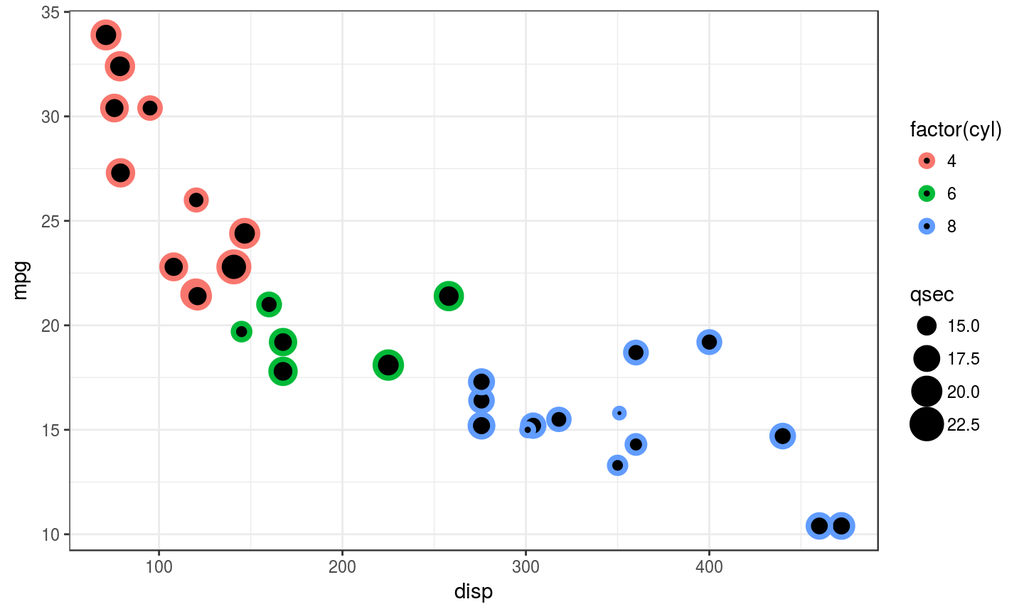

```r
ggplot(mtcars, aes(x=disp, y=mpg)) +
  geom_point(aes(col = factor(cyl), size=qsec), shape=21, stroke=2, fill='black') +
  theme_bw()
```

## `theme_minimal()`

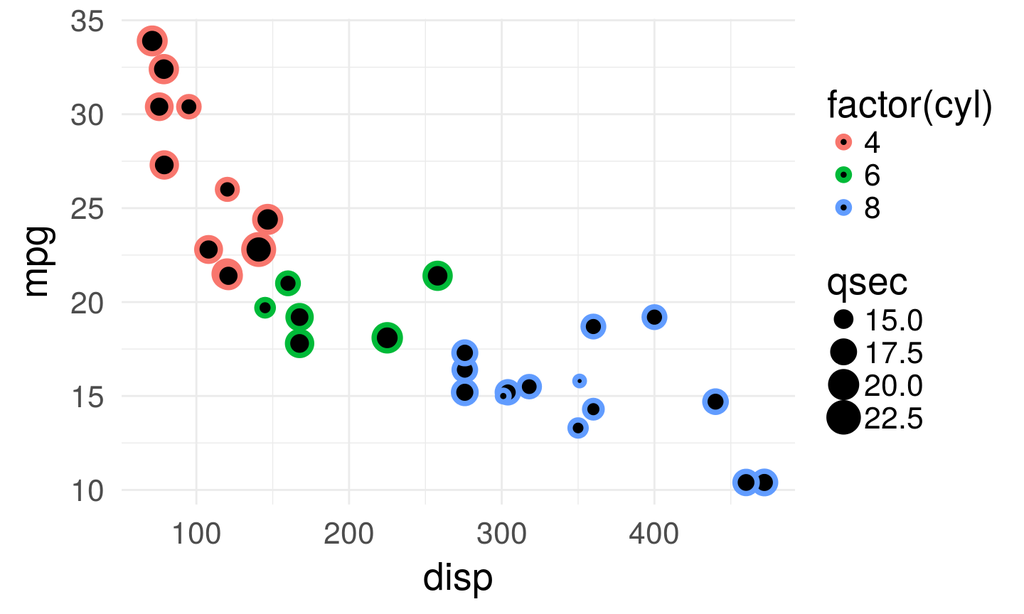

```r
ggplot(mtcars, aes(x=disp, y=mpg)) +
  geom_point(aes(col = factor(cyl), size=qsec), shape=21, stroke=2, fill='black') +
  theme_minimal(base_size = 20)
```

## More themes with `ggthemes`

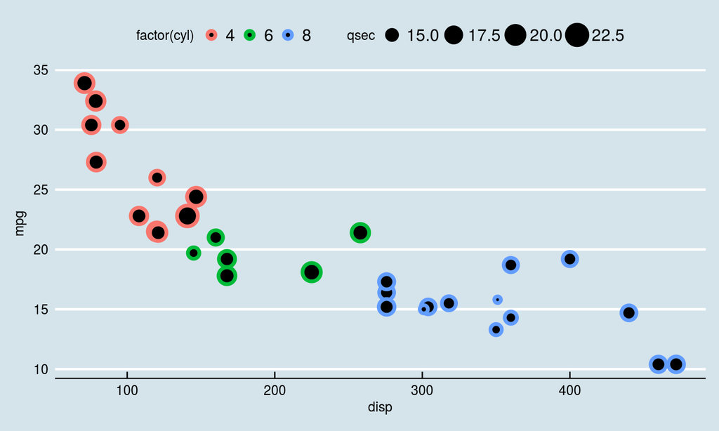

```r
library(ggthemes)
ggplot(mtcars, aes(x=disp, y=mpg)) +
  geom_point(aes(col = factor(cyl), size=qsec), shape=21, stroke=2, fill='black') +
  theme_economist()
```

## Additional resources

- [ggplot2 homepage](http://ggplot2.tidyverse.org/)
- [ggplot2 course on datacamp (paid)](https://www.datacamp.com/courses/data-visualization-with-ggplot2-1)
- [Tutorial from Harvard](http://tutorials.iq.harvard.edu/R/Rgraphics/Rgraphics.html)
- [More tutorials](http://r-statistics.co/Complete-Ggplot2-Tutorial-Part1-With-R-Code.html)
- [Stack overflow](https://stackoverflow.com/questions/tagged/ggplot2)